# Linear Probability Models

Andrew Zieffler

April 01, 2021

# Preparation

In this set of notes, you will learn how about linear probability models, and why they are not typically used to model dichotomous categorical outcome variables (e.g., dummy coded outcome). We will use data from the file *graduation.csv* (see the [data codebook](http://zief0002.github.io/epsy-8252/codebooks/graduation.html)) to explore predictors of college graduation.

```r
# Load libraries
library(broom)
library(corrr)
library(educate)
library(patchwork)
library(tidyverse)

# Read in data
grad = read_csv(file = "~/Documents/github/epsy-8252/data/graduation.csv")

# View data
head(grad)
```

```
# A tibble: 6 x 6
  degree   act scholarship    ap firstgen nontrad
   <dbl> <dbl>       <dbl> <dbl>    <dbl>   <dbl>
1      1    21         0       0        0       0
2      1    19         0       0        0       0
3      1    27         0       0        1       0
4      1    25         0.5     0        1       0
5      0    28         0      17        1       0
6      1    21         0       0        0       1
```

Note that in these analyses the outcome variable (`degree`) is a dichotomous dummy-coded categorical variable indicating whether or not a student graduated.

# Data Exploration

To begin the analysis, we will explore the outcome variable `degree`. Since this is a categorical variable, we can look at counts and proportions. The analysis suggests that most students in the sample tend to graduate (73%).

```r
grad %>%
  group_by(degree) %>%
  summarize(
    Count = n(),
    Prop = n() / nrow(grad)
    )
```

```
# A tibble: 2 x 3
  degree Count  Prop
   <dbl> <int> <dbl>
1      0   627 0.267
2      1  1717 0.733
```

We will also explore the `act` variable, which we will use as a predictor in the analysis.

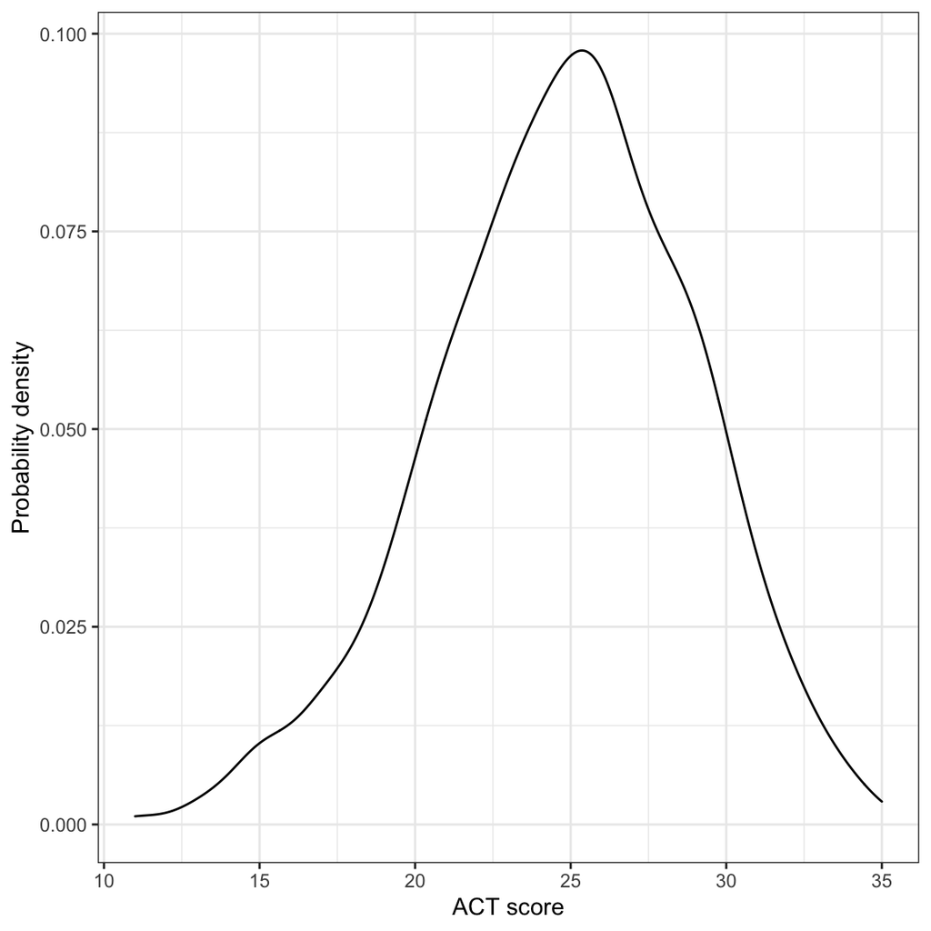

Density plot of the ACT scores.

```r
# Density plot
ggplot(data = grad, aes(x = act)) +
  geom_density() +
  theme_bw() +
  xlab("ACT score") +
  ylab("Probability density")
```

```r
# Summary measures
grad %>%
  summarize(
    M = mean(act),
    SD = sd(act)
    )
```

```
# A tibble: 1 x 2
      M    SD
  <dbl> <dbl>
1  24.8  4.15
```

## Relationship between ACT Score and Graduation

When the outcome variable was continous, we examined relationships graphically via a scatterplot. If we try that when the outcome is dichotomous, we run into problems. Since there are only two values for the outcome, many of the observations are over-plotted, and it is impossible to tell anything about the relationship between the variables.

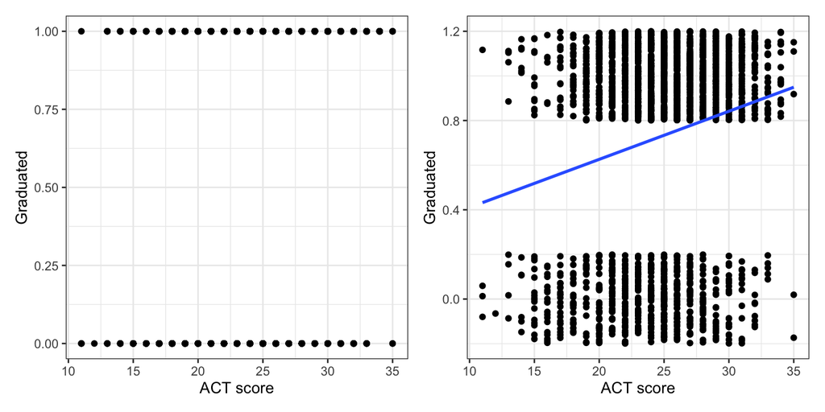

Scatterplot of whether a student graduated versus ACT score. In the right-hand plot, the points have been jittered to alleviate over-plotting, and the regression smoother has also been added to the plot.

```r
# Scatterplot
p1 = ggplot(data = grad, aes(x = act, y = degree)) +
  geom_point() +
  theme_bw() +
  xlab("ACT score") +
  ylab("Graduated")

# Jittered scatterplot
p2 = ggplot(data = grad, aes(x = act, y = jitter(degree))) +
  geom_point() +
  geom_smooth(method = "lm", se = FALSE) +
  theme_bw() +
  xlab("ACT score") +
  ylab("Graduated")

# Display plots
p1 | p2
```

One solution to this problem is to add (or subtract) a tiny amount of noise to each student’s `degree` value. This is called “jittering” the observations". To do this, use the `jitter()` function. (Note that the amount of jittering can be adjusted by including an additional argument to the `jitter()` function.) This spreads out the observations vertically, so we no longer have the problem of overplotting. But, the relationship is still difficult to see in this scatterplot. Adding the regression smoother helps us see that there is a positive relationship between ACT scores and graduation.

How do we interpret this plot and the relationship shown in the fitted regression line? To understand this, we have to think about what the linear regression is modeling. Remember that the regression model is predicting the average *Y* at each *X*. Since our *Y* is dichotomous, the average represents the proportion of students with a 1. **In other words, the regression predicts the proportion of students who graduate for a particular ACT score.**

The positive relationship between ACT score and graduation suggests that higher ACT scores are associated with higher proportions of students who graduate. We can also see this relationship by examining the correlation matrix between the two variables.

```r
# Correlation
grad %>%
  select(degree, act) %>%
  correlate()
```

```
# A tibble: 2 x 3
  term   degree    act
  <chr>   <dbl>  <dbl>
1 degree NA      0.195
2 act     0.195 NA
```

# Fitting the Linear Probability (Proportion) Model

We can fit the linear model shown in the plot using the `lm()` function as we always have. The name of this model when we have a dichotomous outcome in a linear model, is the *linear probability (proportion) model*.

```r
# Fit the model
lm.1 = lm(degree ~ 1 + act, data = grad)

# Model-level- output
glance(lm.1)
```

```
# A tibble: 1 x 12
  r.squared adj.r.squared sigma statistic  p.value    df logLik   AIC   BIC
      <dbl>         <dbl> <dbl>     <dbl>    <dbl> <dbl>  <dbl> <dbl> <dbl>
1    0.0381        0.0377 0.434      92.7 1.50e-21     1 -1370. 2746. 2764.
# … with 3 more variables: deviance <dbl>, df.residual <int>, nobs <int>
```

Differences in ACT score account for 3.8% of the variation in graduation.

```r
# Coefficient-level- output
tidy(lm.1)
```

```
# A tibble: 2 x 5
  term        estimate std.error statistic  p.value
  <chr>          <dbl>     <dbl>     <dbl>    <dbl>
1 (Intercept)   0.217    0.0543       3.99 6.79e- 5
2 act           0.0208   0.00216      9.63 1.50e-21
```

The fitted model is

$$\hat{\pi}_i = 0.22 + 0.02(\mathrm{ACT~Score}_i)$$

where $\hat{\pi}_i$ is the predicted proportion of students who graduate. Interpreting the coefficients,

- On average, 0.22 of students having an ACT score of 0 are predicted to graduate. (Extrapolation)
- Each one-point difference in ACT score is associated with an additional 0.02 predicted improvement in the proportion of students graduating, on average.

Let’s examine the model assumptions.

```r
# Augment the model
out = augment(lm.1)

# View augmented data
out
```

```
# A tibble: 2,344 x 8
   degree   act .fitted .resid     .hat .sigma   .cooksd .std.resid
    <dbl> <dbl>   <dbl>  <dbl>    <dbl>  <dbl>     <dbl>      <dbl>
 1      1    21   0.654  0.346 0.000777  0.434 0.000246       0.796
 2      1    19   0.613  0.387 0.00125   0.434 0.000498       0.893
 3      1    27   0.779  0.221 0.000552  0.434 0.0000713      0.508
 4      1    25   0.738  0.262 0.000428  0.434 0.0000782      0.604
 5      0    28   0.800 -0.800 0.000688  0.434 0.00117       -1.84
 6      1    21   0.654  0.346 0.000777  0.434 0.000246       0.796
 7      1    27   0.779  0.221 0.000552  0.434 0.0000713      0.508
 8      0    20   0.633 -0.633 0.000988  0.434 0.00105       -1.46
 9      1    26   0.758  0.242 0.000465  0.434 0.0000720      0.556
10      1    25   0.738  0.262 0.000428  0.434 0.0000782      0.604
# … with 2,334 more rows
```

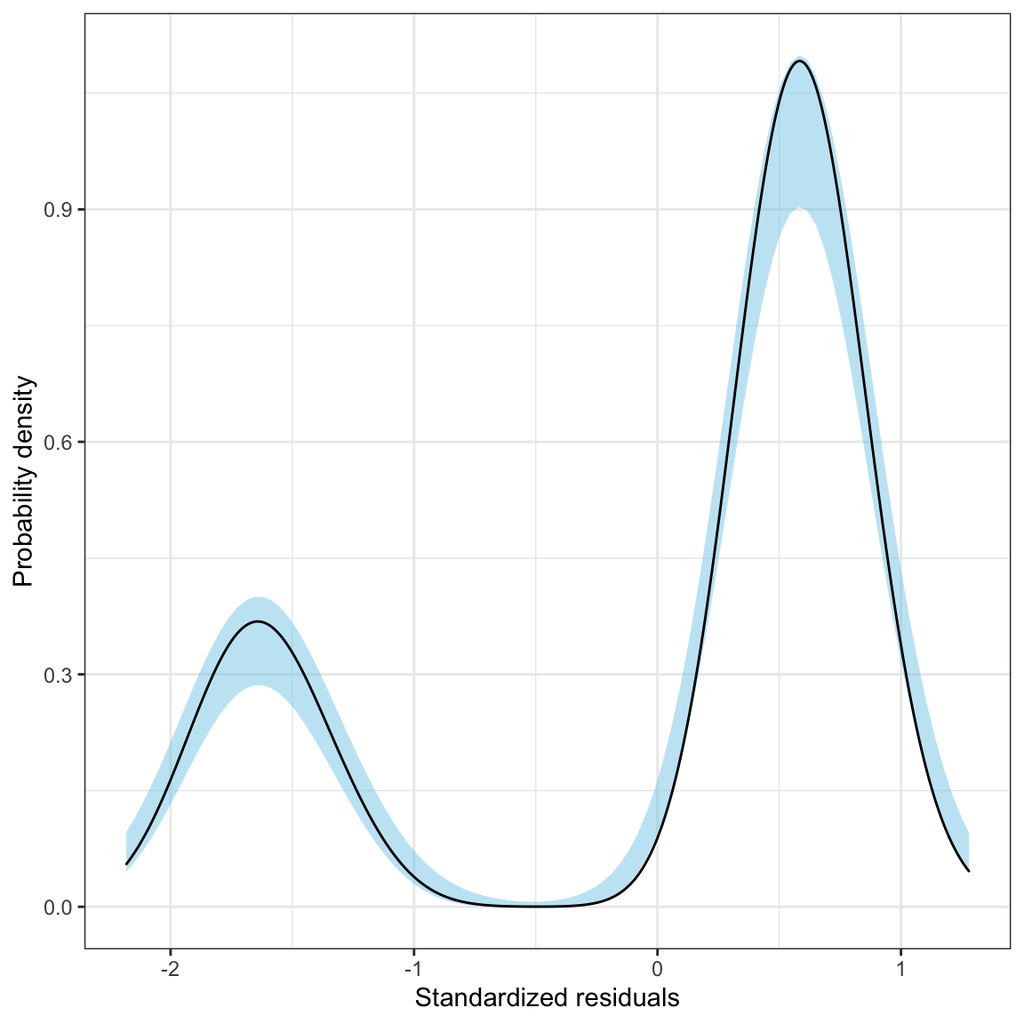

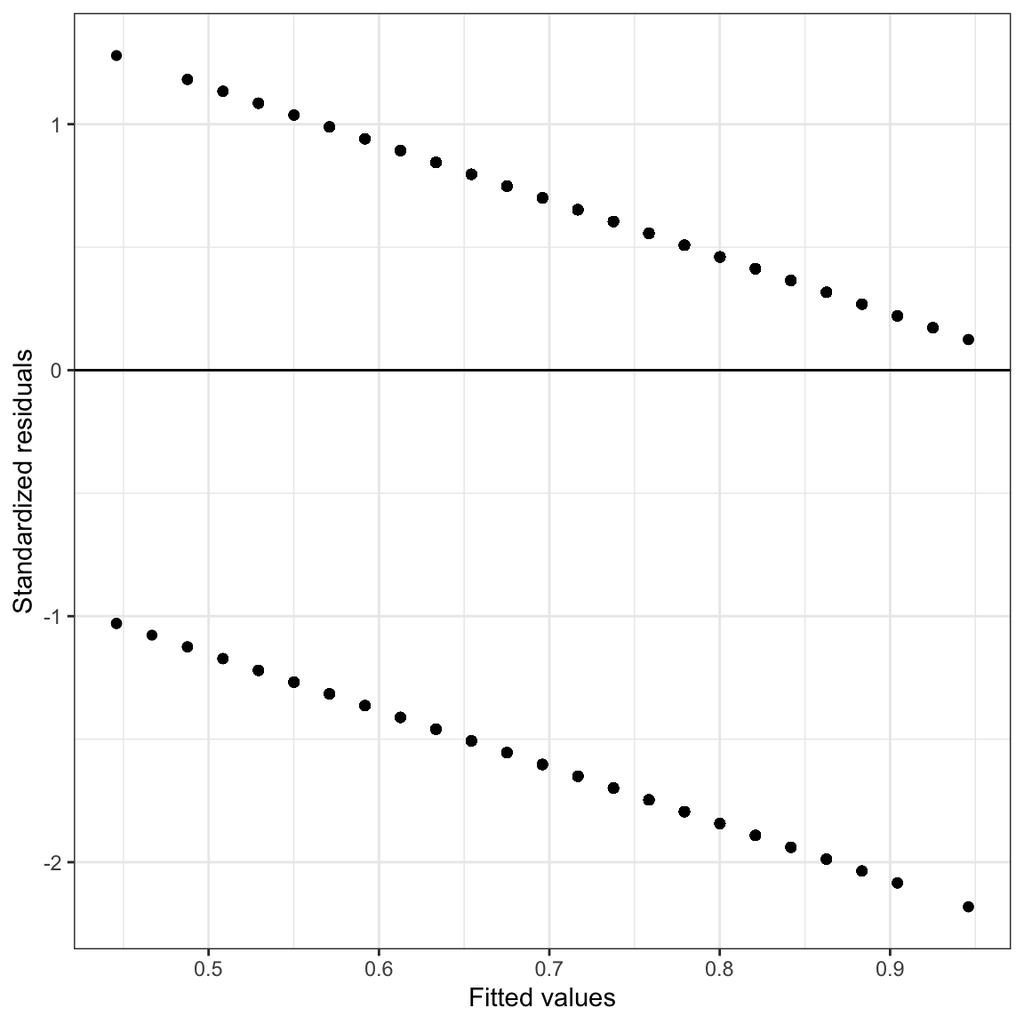

LEFT: Density plot of the standardized residuals from the linear probability model. RIGHT: Scatterplot of the standardized residuals versus the fitted values from the linear probability model.

```r
# Examine normality assumption
ggplot(data = out, aes(x = .std.resid)) +
  stat_density_confidence() +
  geom_density() +
  theme_bw() +
  xlab("Standardized residuals") +
  ylab("Probability density")

# Examine linearity and homoskedasticity
ggplot(data = out, aes(x = .fitted, y = .std.resid)) +
  geom_point() +
  geom_hline(yintercept = 0) +
  theme_bw() +
  xlab("Fitted values") +
  ylab("Standardized residuals")
```

It is clear that the assumptions associated with linear regression are violated. First off, the residuals are not normally distributed. They are in fact, bimodal. The scatterplot of the residuals versus the fitted values also indicates violation of the linearity assumption, as the average residual at each fitted value is not zero.

## Understanding the Residuals from the Linear Probability Model

Look closely at the scatterplot of the residuals versus the fitted values. At each fitted value, there are only two residual values. Why is this? Recall that residuals are computed as $\epsilon_i=Y_i - \hat{Y}_i$. Now, remember that $Y_i$ can only be one of two values, 0 or 1. Also remember that in the linear probability model $\hat{Y}_i=\hat{\pi}_i$. Thus, for $Y=0$,

$$\begin{split}
\epsilon_i &= 0 - \hat{Y}_i \\
&= - \hat{\pi}_i
\end{split}$$

And, if $Y=1$,

$$\begin{split}
\epsilon_i &= 1 - \hat{Y}_i \\
&= 1 - \hat{\pi}_i
\end{split}$$

This means that the residual computed using a particular fitted value (or from a particular ACT value given that the fitted values is a function of $X$) can only take on one of two values: $- \hat{\pi}_i$ or $1 - \hat{\pi}_i$. (Plotting the residuals for all fitted values, the marginal distribution of the residuals, results in a bimodal distribution for this same reason.)

Fitting a linear model when the outcome is dichotomous will result in gross violations of the distributional assumptions. In class we will examine more appropriate models for modeling variation in dichotomous outcomes.